# Analysing QIIME2 data with phyloseq.

## Introduction

In this script, we will explore the imported dataset from QIIME2 using qiime2R and phyloseq.

We will also rarefy the data for future analyses.

We will use the data from 001-phyloseq-qiime2.R script (ps.q.agg agglomerated tables at phylum, family, genus, and OTU level).

## Load necessary libraries and scripts.

```r
# install.packages(c("tidyverse","vegan","ggtext","Polychrome","ggrepel"))
library(tidyverse)
```

```
## ✖ purrr::%||%()   masks base::%||%()
```

```r
library(vegan)
library(Polychrome)
library(ggtext)
library(ggrepel)
```

## Import the config file.

```r
# cmdargs <- commandArgs(trailingOnly = TRUE)
# active.analysis <- cmdargs[1]
unlockBinding("params", env = .GlobalEnv)
active.analysis <- params$active.analysis
print(paste("The analysis focus is:", active.analysis))
```

```
## [1] "The analysis focus is: all_domains"
```

```r
source(here::here("config/R/config.R"))# config file with global variables
source(here::here("config/R/themes.R"))# config file with themes
```

Import datasets as rds files.

```r
ps.q.agg.asv<-readRDS(file = ps.q.agg.asv.fname)
ps.q.agg.genus <- readRDS(file = ps.q.agg.genus.fname)
ps.q.agg.family <- readRDS(file = ps.q.agg.family.fname)
ps.q.agg.phylum<-readRDS(file = ps.q.agg.phylum.fname)
custom.md <- readRDS(custom.md.path)
custom.levels<-intersect(names(pretty.level.names),custom.md$class)
```

Load necessary scripts.

```r
source("./code/r-scripts/get_n_uniq_taxa_per_host.R")
source("./code/r-scripts/create_summary_stats_table.R")
source("./code/r-scripts/add_relab_to_tax_df.R")
source("./code/r-scripts/add_agegroup_to_tax_df.R")
source("./code/r-scripts/get_unclassified_summary_stats.R")
source("./code/r-scripts/get_dominant_taxa_in_host.R")
source("./code/r-scripts/ggplot_species.R")
```

## Calculating summary statistics.

### Check the total number of unique ASV/phyla/families/genera per class.

We will use it for the summary table in the next section.

```r
n.asv.per.host<-get_n_uniq_taxa_per_host(ps.q.agg.asv,"OTU")
n.phylum.per.host<-get_n_uniq_taxa_per_host(ps.q.agg.phylum,"Phylum")
n.family.per.host<-get_n_uniq_taxa_per_host(ps.q.agg.family,"Family")
n.genus.per.host<-get_n_uniq_taxa_per_host(ps.q.agg.genus,"Genus")
```

### Create a summary table.

The columns are:  
- Total reads  
- Library size (mean Abundance ± SD)  
- Number of ASV per host  
- Number of phyla per host  
- Number of families per host  
- Number of genera per host

```r
summary.stats.table<-create_summary_stats_table(ps.q.agg.asv,
                                                n.asv.per.host,
                                                n.phylum.per.host,
                                                n.family.per.host,
                                                n.genus.per.host)
knitr::kable(as.data.frame(summary.stats.table),format = "simple")
```

| class | TotalSamplesPerHost | TotalReadsPerHost | MeanLibrarySize | SDLibrarySize | ASVPerHost | PhylaPerHost | FamiliesPerHost | GeneraPerHost |
| --- | --- | --- | --- | --- | --- | --- | --- | --- |
| B6mouse | 4 | 350560 | 87640 | 9604 | 949 | 13 | 57 | 126 |
| DMR | 20 | 3226967 | 161348 | 68609 | 1833 | 24 | 159 | 261 |
| FVBNmouse | 3 | 236970 | 78990 | 9119 | 679 | 13 | 54 | 119 |
| hare | 8 | 2923993 | 365499 | 48718 | 1480 | 15 | 88 | 174 |
| MSMmouse | 8 | 614001 | 76750 | 8153 | 934 | 13 | 64 | 136 |
| NMR | 24 | 1846190 | 76925 | 26280 | 1876 | 22 | 115 | 235 |
| pvo | 10 | 808852 | 80885 | 60885 | 2029 | 14 | 97 | 187 |
| rabbit | 7 | 2417396 | 345342 | 70862 | 3458 | 15 | 103 | 190 |
| spalax | 15 | 539095 | 35940 | 11383 | 1290 | 10 | 53 | 114 |

```r
summary.stats.table.fname<-file.path(community.composition.tables,
  "summary-table.tsv")
if(!file.exists(summary.stats.table.fname)){
  write.table(summary.stats.table,
              file=summary.stats.table.fname,
              row.names = F,sep = "\t")
}
```

## Add relative abundance and average relative abundance columns.

```r
ps.q.agg.phylum.relab<-add_relab_to_tax_df(ps.q.agg.phylum,"Phylum")
ps.q.agg.family.relab<-add_relab_to_tax_df(ps.q.agg.family,"Family")
ps.q.agg.genus.relab<-add_relab_to_tax_df(ps.q.agg.genus,"Genus")
ps.q.agg.asv.relab<-add_relab_to_tax_df(ps.q.agg.asv,"OTU")
knitr::kable(head(ps.q.agg.phylum.relab),format = "simple")
```

| Sample | Abundance | class | Kingdom | Phylum | RelativeAbundance | MeanRelativeAbundance | TotalSample | TotalClass | TotalAgglomRank | sdRelativeAbundance |
| --- | --- | --- | --- | --- | --- | --- | --- | --- | --- | --- |
| MF_153 | 391461 | rabbit | Bacteria | Firmicutes | 94.36001 | 83.95703 | 414859 | 2417396 | 2029574 | 8.367420 |
| MF_154 | 363129 | rabbit | Bacteria | Firmicutes | 89.56108 | 83.95703 | 405454 | 2417396 | 2029574 | 8.367420 |
| MF_144 | 305772 | rabbit | Bacteria | Firmicutes | 87.31453 | 83.95703 | 350196 | 2417396 | 2029574 | 8.367420 |
| MF_151 | 287896 | hare | Bacteria | Firmicutes | 69.04858 | 60.54963 | 416947 | 2923993 | 1770467 | 6.949763 |
| MF_140 | 275649 | rabbit | Bacteria | Firmicutes | 84.65592 | 83.95703 | 325611 | 2417396 | 2029574 | 8.367420 |
| MF_136 | 267945 | hare | Bacteria | Firmicutes | 64.47355 | 60.54963 | 415589 | 2923993 | 1770467 | 6.949763 |

```r
knitr::kable(head(ps.q.agg.family.relab),format = "simple")
```

| Sample | Abundance | class | Kingdom | Phylum | Class | Order | Family | RelativeAbundance | MeanRelativeAbundance | TotalSample | TotalClass | TotalAgglomRank | sdRelativeAbundance |
| --- | --- | --- | --- | --- | --- | --- | --- | --- | --- | --- | --- | --- | --- |
| MF_153 | 351733 | rabbit | Bacteria | Firmicutes | Clostridia | Clostridiales | Clostridiaceae | 84.78375 | 22.862162 | 414859 | 2417396 | 552669 | 39.280856 |
| MF_144 | 192256 | rabbit | Bacteria | Firmicutes | Clostridia | Clostridiales | Clostridiaceae | 54.89954 | 22.862162 | 350196 | 2417396 | 552669 | 39.280856 |
| MF_143 | 131605 | rabbit | Bacteria | Firmicutes | Clostridia | Peptostreptococcales-Tissierellales | Peptostreptococcaceae | 35.78129 | 5.444536 | 367804 | 2417396 | 131616 | 20.657263 |
| F568 | 122474 | DMR | Bacteria | Bacteroidota | Bacteroidia | Bacteroidales | Muribaculaceae | 38.11329 | 28.822359 | 321342 | 3226967 | 930088 | 7.707617 |
| MF_140 | 113241 | rabbit | Bacteria | Firmicutes | Clostridia | Oscillospirales | Ruminococcaceae | 34.77800 | 16.540443 | 325611 | 2417396 | 399848 | 10.534445 |
| MF_136 | 112693 | hare | Bacteria | Firmicutes | Clostridia | Lachnospirales | Lachnospiraceae | 27.11645 | 17.310575 | 415589 | 2923993 | 506160 | 7.163299 |

```r
knitr::kable(head(ps.q.agg.genus.relab),format = "simple")
```

| Sample | Abundance | class | Kingdom | Phylum | Class | Order | Family | Genus | RelativeAbundance | MeanRelativeAbundance | TotalSample | TotalClass | TotalAgglomRank | sdRelativeAbundance |
| --- | --- | --- | --- | --- | --- | --- | --- | --- | --- | --- | --- | --- | --- | --- |
| MF_153 | 351692 | rabbit | Bacteria | Firmicutes | Clostridia | Clostridiales | Clostridiaceae | Clostridium_sensu_stricto_1 | 84.77386 | 21.307556 | 414859 | 2417396 | 515088 | 40.983550 |
| MF_144 | 163176 | rabbit | Bacteria | Firmicutes | Clostridia | Clostridiales | Clostridiaceae | Clostridium_sensu_stricto_1 | 46.59562 | 21.307556 | 350196 | 2417396 | 515088 | 40.983550 |
| MF_143 | 131605 | rabbit | Bacteria | Firmicutes | Clostridia | Peptostreptococcales-Tissierellales | Peptostreptococcaceae | Peptostreptococcaceae Family | 35.78129 | 5.444247 | 367804 | 2417396 | 131609 | 25.299785 |
| F568 | 120752 | DMR | Bacteria | Bacteroidota | Bacteroidia | Bacteroidales | Muribaculaceae | Muribaculaceae | 37.57741 | 28.378846 | 321342 | 3226967 | 915776 | 7.718868 |
| MF_136 | 103379 | hare | Bacteria | Firmicutes | Clostridia | Lachnospirales | Lachnospiraceae | Lachnospiraceae Family | 24.87530 | 13.187138 | 415589 | 2923993 | 385591 | 5.512814 |
| F541 | 93198 | DMR | Bacteria | Bacteroidota | Bacteroidia | Bacteroidales | Muribaculaceae | Muribaculaceae | 31.58130 | 28.378846 | 295105 | 3226967 | 915776 | 7.718868 |

```r
knitr::kable(head(ps.q.agg.asv.relab),format = "simple")
```

| OTU | Sample | Abundance | class | Kingdom | Phylum | Class | Order | Family | Genus | Species | RelativeAbundance | MeanRelativeAbundance | TotalSample | TotalClass | TotalAgglomRank | sdRelativeAbundance |
| --- | --- | --- | --- | --- | --- | --- | --- | --- | --- | --- | --- | --- | --- | --- | --- | --- |
| 29e99f83bf74e2c276889f59dd2273d9 | MF_153 | 317376 | rabbit | Bacteria | Firmicutes | Clostridia | Clostridiales | Clostridiaceae | Clostridium_sensu_stricto_1 | Clostridium_sensu_stricto_1 Genus | 76.50214 | 13.136739 | 414859 | 2417396 | 317567 | 54.05370 |
| c731b1a9b4e1bd001eb1c8792790362e | MF_144 | 144914 | rabbit | Bacteria | Firmicutes | Clostridia | Clostridiales | Clostridiaceae | Clostridium_sensu_stricto_1 | Clostridium_sensu_stricto_1 Genus | 41.38083 | 5.994632 | 350196 | 2417396 | 144914 | NA |
| dc17e8817f23d1fe78b4fc3a7a196f53 | MF_143 | 109556 | rabbit | Bacteria | Firmicutes | Clostridia | Peptostreptococcales-Tissierellales | Peptostreptococcaceae | Peptostreptococcaceae Family | Peptostreptococcaceae Family | 29.78652 | 4.532150 | 367804 | 2417396 | 109560 | 21.06084 |
| a45df882254eed21da6066c7ad4e7664 | MF_143 | 87032 | rabbit | Bacteria | Verrucomicrobiota | Verrucomicrobiae | Verrucomicrobiales | Akkermansiaceae | Akkermansia | Akkermansia Genus | 23.66260 | 4.233398 | 367804 | 2417396 | 102338 | 11.12854 |
| 2972be1fd57d3e53b21e75d28248aa50 | MF_140 | 67455 | rabbit | Bacteria | Firmicutes | Clostridia | Oscillospirales | Ruminococcaceae | Ruminococcus | uncultured_Clostridiaceae | 20.71644 | 2.791268 | 325611 | 2417396 | 67476 | 14.64515 |
| 4514fcefdb82718d97b412184a893dc2 | F519 | 65842 | DMR | Bacteria | Proteobacteria | Gammaproteobacteria | Enterobacterales | Enterobacteriaceae | Escherichia-Shigella | Escherichia-Shigella Genus | 39.10484 | 2.053786 | 168373 | 3226967 | 66275 | 14.75873 |

## Add agegroup variable to NMR data.

```r
custom.md.ages<-readRDS(file.path(new.metadata.dir,"custom.md.ages.rds"))%>%
  filter(sequencing_type == "Naked mole-rat 16S rRNA gene sequencing")

ps.q.agg.genus.relab.nmr<-ps.q.agg.genus.relab%>%
  filter(class=="NMR")

ps.q.agg.asv.relab.nmr<-ps.q.agg.asv.relab%>%
  filter(class=="NMR")
```

Add the age groups.

```r
ps.q.agg.genus.relab.nmr<-add_agegroup_to_tax_df(ps.q.agg.genus.relab.nmr,"Genus",
                                             custom.md.ages)
ps.q.agg.asv.relab.nmr<-add_agegroup_to_tax_df(ps.q.agg.asv.relab.nmr,"OTU",
                                       custom.md.ages)
knitr::kable(head(ps.q.agg.genus.relab.nmr),format = "simple")
```

| Sample | Abundance | class | Kingdom | Phylum | Class | Order | Family | Genus | RelativeAbundance | MeanRelativeAbundance | TotalSample | TotalClass | TotalAgglomRank | sdRelativeAbundance | agegroup | MeanRelativeAbundanceAgegroup |
| --- | --- | --- | --- | --- | --- | --- | --- | --- | --- | --- | --- | --- | --- | --- | --- | --- |
| CG33 | 22665 | NMR | Bacteria | Firmicutes | Clostridia | Eubacteriales | Eubacteriaceae | Eubacteriaceae Family | 20.15419 | 7.945661 | 112458 | 1846190 | 146692 | 5.727540 | agegroup0_10 | 8.733922 |
| 2D10 | 17907 | NMR | Bacteria | Firmicutes | Bacilli | Erysipelotrichales | Erysipelotrichaceae | Allobaculum | 20.46631 | 5.200331 | 87495 | 1846190 | 96008 | 6.263887 | agegroup0_10 | 5.560337 |
| D27 | 16698 | NMR | Bacteria | Firmicutes | Clostridia | Eubacteriales | Eubacteriaceae | Eubacteriaceae Family | 16.95986 | 7.945661 | 98456 | 1846190 | 146692 | 5.727540 | agegroup0_10 | 8.733922 |
| 2D14 | 16108 | NMR | Bacteria | Firmicutes | Bacilli | Erysipelotrichales | Erysipelotrichaceae | Allobaculum | 17.87851 | 5.200331 | 90097 | 1846190 | 96008 | 6.263887 | agegroup0_10 | 5.560337 |
| L133 | 15999 | NMR | Bacteria | Bacteroidota | Bacteroidia | Bacteroidales | Muribaculaceae | Muribaculaceae | 15.01534 | 11.113157 | 106551 | 1846190 | 205170 | 3.129073 | agegroup0_10 | 10.952119 |
| Y66b | 15163 | NMR | Bacteria | Bacteroidota | Bacteroidia | Bacteroidales | Muribaculaceae | Muribaculaceae | 16.15353 | 11.113157 | 93868 | 1846190 | 205170 | 3.129073 | agegroup0_10 | 10.952119 |

```r
knitr::kable(head(ps.q.agg.asv.relab.nmr),format = "simple")
```

| OTU | Sample | Abundance | class | Kingdom | Phylum | Class | Order | Family | Genus | Species | RelativeAbundance | MeanRelativeAbundance | TotalSample | TotalClass | TotalAgglomRank | sdRelativeAbundance | agegroup | MeanRelativeAbundanceAgegroup |
| --- | --- | --- | --- | --- | --- | --- | --- | --- | --- | --- | --- | --- | --- | --- | --- | --- | --- | --- |
| 775f1d61e616978239ee36c337b0403c | D27 | 12318 | NMR | Bacteria | Firmicutes | Clostridia | Eubacteriales | Eubacteriaceae | Eubacteriaceae Family | Eubacteriaceae Family | 12.51117 | 1.736766 | 98456 | 1846190 | 32064 | 3.493833 | agegroup0_10 | 1.767471 |
| fbcb14cd27216d317b57152441189a35 | 2D10 | 12293 | NMR | Bacteria | Firmicutes | Bacilli | Erysipelotrichales | Erysipelotrichaceae | Allobaculum | Allobaculum Genus | 14.04995 | 3.278265 | 87495 | 1846190 | 60523 | 4.293673 | agegroup0_10 | 3.460320 |
| 5a818007a6452d5db9223ef1388e451c | DCG6 | 11288 | NMR | Bacteria | Bacteroidota | Bacteroidia | Bacteroidales | p-251-o5 | p-251-o5 | p-251-o5 Genus | 12.57380 | 6.303360 | 89774 | 1846190 | 116372 | 3.723657 | agegroup0_10 | 6.655592 |
| 2a9b76ddc8fc1e5f0e10f1fd40de1c79 | L122 | 10857 | NMR | Bacteria | Fibrobacterota | Fibrobacteria | Fibrobacterales | Fibrobacteraceae | Fibrobacter | Fibrobacter Genus | 11.38396 | 4.156885 | 95371 | 1846190 | 76744 | 3.639603 | agegroup0_10 | 3.899673 |
| fbcb14cd27216d317b57152441189a35 | 2D14 | 10674 | NMR | Bacteria | Firmicutes | Bacilli | Erysipelotrichales | Erysipelotrichaceae | Allobaculum | Allobaculum Genus | 11.84723 | 3.278265 | 90097 | 1846190 | 60523 | 4.293673 | agegroup0_10 | 3.460320 |
| 5a818007a6452d5db9223ef1388e451c | GA17 | 10346 | NMR | Bacteria | Bacteroidota | Bacteroidia | Bacteroidales | p-251-o5 | p-251-o5 | p-251-o5 Genus | 10.13996 | 6.303360 | 102032 | 1846190 | 116372 | 3.723657 | agegroup0_10 | 6.655592 |

## Calculate summary stats of unclassified genera in each animal (unrarefied).

Here, we are interested in unclassified genera, but you can also try Families, Orders, Classes, etc.

```r
all.ranks<-c("Kingdom", "Phylum", "Class", "Order", "Family","Genus")
agglom.rank<-"Genus"
unclassified.genus.summary.stats.table<-
  get_unclassified_summary_stats(ps.q.agg.genus.relab,"Genus")
knitr::kable(unclassified.genus.summary.stats.table, format ="simple")
```

| class | MeanTotalUnclassifiedPercent | SDTotalUnclassifiedPercent | minTotalUnclassifiedPercent | maxTotalUnclassifiedPercent | MedianTotalUnclassifiedPercent | NumUnclassifiedTaxa | NumClassifiedTaxa | MinTotalTaxa | MaxTotalTaxa |
| --- | --- | --- | --- | --- | --- | --- | --- | --- | --- |
| pvo | 33 | 12 | 14 | 52 | 29 | 38 | 149 | 51 | 105 |
| NMR | 29 | 6 | 17 | 42 | 29 | 54 | 181 | 95 | 146 |
| hare | 28 | 8 | 18 | 44 | 26 | 53 | 121 | 103 | 126 |
| DMR | 26 | 11 | 6 | 51 | 28 | 76 | 185 | 81 | 124 |
| rabbit | 23 | 15 | 6 | 48 | 23 | 53 | 137 | 80 | 126 |
| MSMmouse | 13 | 9 | 7 | 33 | 10 | 25 | 111 | 76 | 99 |
| B6mouse | 11 | 6 | 4 | 19 | 11 | 21 | 105 | 72 | 108 |
| spalax | 10 | 7 | 2 | 31 | 8 | 21 | 93 | 26 | 56 |
| FVBNmouse | 9 | 7 | 4 | 17 | 7 | 22 | 97 | 89 | 109 |

```r
unclassified.genus.summary.stats.table.fname <-
  file.path(community.composition.tables,
            "unclassified-genus-summary-table.tsv")
if (! file.exists(unclassified.genus.summary.stats.table.fname)){
  write.table(unclassified.genus.summary.stats.table,
              file = unclassified.genus.summary.stats.table.fname,
              row.names = F,sep = "\t")
}
```

## Rarefy the table and check the percentage of unclassified taxa.

Convert the data frame into wide format: rows are samples and columns are taxa

```r
get_rarefied_table<-function(tax.df,tax.rank,host.classes){
  tax.df.wide<-tax.df%>%
    filter(class %in% host.classes,Abundance!=0)%>%
    dplyr::select(Sample,Abundance,class,all_of(tax.rank))%>%
    filter(Abundance!=0)%>%
    pivot_wider(names_from = all_of(tax.rank),
                values_from = "Abundance",
                values_fill = 0)%>%
    as.data.frame()%>%
    column_to_rownames("Sample")%>% # Set sample names as row names
    dplyr::select(-class)
  # Find the smallest sample size
  min.n_seqs.all<-tax.df%>%
    filter(class %in% host.classes,Abundance!=0)%>%
    dplyr::select(Sample,all_of(tax.rank),Abundance)%>%
    group_by(Sample)%>%
    summarize(n_seqs=sum(Abundance))%>%
    summarize(min=min(n_seqs))%>%
    pull(min)
  print(paste("Smallest sample size:", min.n_seqs.all))

  ### Rarefied asv table with vegan ####
  set.seed(1)
  tax.df.rare<-rrarefy(tax.df.wide,sample=min.n_seqs.all)
  tax.df.rare<-tax.df.rare%>%
    as_tibble(rownames="Sample")%>%
    pivot_longer(-Sample)%>%
    as.data.frame()%>%
    left_join(unique(tax.df[,c("Sample","class")]),
              by="Sample")
  if(tax.rank=="OTU"){
    tax.df.rare<-tax.df.rare%>%
      rename(OTU=name,Abundance=value)%>%
      filter(Abundance!=0)
  }else{
    # rename the 'name' column corresponding to the tax.rank
    tax.df.rare[,paste(tax.rank)]<-tax.df.rare$name
    tax.df.rare<-tax.df.rare%>%
      dplyr::select(-name)%>%
      rename(Abundance=value)%>%
      filter(Abundance!=0)
  }
  rare.table.fname <- file.path(community.composition.tables,
                                paste0(
                                  paste("ps.q.df.rare-nonfiltered",tax.rank,
                                        paste(host.classes,collapse = '-'),sep = "-"),
                                  ".tsv"))
  if(! file.exists (rare.table.fname)){
    write.table(tax.df.rare,
                file = rare.table.fname,
                row.names = F,
                sep = "\t")

  }

  rda.fname <- file.path(community.composition.rdafiles,paste0(
    paste("ps.q.df.rare-nonfiltered",tax.rank,
      paste(host.classes,collapse = '-'),sep = "-"),
    ".rds"))
  if(! file.exists(rda.fname)){
    saveRDS(tax.df.rare,
            file = rda.fname)
  }
  return(tax.df.rare)
}

ps.q.agg.asv.rare<-get_rarefied_table(ps.q.agg.asv,"OTU",custom.levels)
```

```
## [1] "Smallest sample size: 21924"
```

```r
ps.q.agg.phylum.rare<-get_rarefied_table(ps.q.agg.phylum,"Phylum",custom.levels)
```

```
## [1] "Smallest sample size: 21924"
```

```r
ps.q.agg.family.rare<-get_rarefied_table(ps.q.agg.family,"Family",custom.levels)
```

```
## [1] "Smallest sample size: 21924"
```

```r
ps.q.agg.genus.rare<-get_rarefied_table(ps.q.agg.genus,"Genus",custom.levels)
```

```
## [1] "Smallest sample size: 21924"
```

```r
ps.q.agg.genus.nmr.rare<-get_rarefied_table(ps.q.agg.genus.relab.nmr,"Genus","NMR")
```

```
## [1] "Smallest sample size: 25435"
```

```r
ps.q.agg.asv.nmr.rare<-get_rarefied_table(ps.q.agg.asv.relab.nmr,"OTU","NMR")
```

```
## [1] "Smallest sample size: 25435"
```

```r
knitr::kable(head(ps.q.agg.asv.relab.nmr),format = "simple")
```

| OTU | Sample | Abundance | class | Kingdom | Phylum | Class | Order | Family | Genus | Species | RelativeAbundance | MeanRelativeAbundance | TotalSample | TotalClass | TotalAgglomRank | sdRelativeAbundance | agegroup | MeanRelativeAbundanceAgegroup |
| --- | --- | --- | --- | --- | --- | --- | --- | --- | --- | --- | --- | --- | --- | --- | --- | --- | --- | --- |
| 775f1d61e616978239ee36c337b0403c | D27 | 12318 | NMR | Bacteria | Firmicutes | Clostridia | Eubacteriales | Eubacteriaceae | Eubacteriaceae Family | Eubacteriaceae Family | 12.51117 | 1.736766 | 98456 | 1846190 | 32064 | 3.493833 | agegroup0_10 | 1.767471 |
| fbcb14cd27216d317b57152441189a35 | 2D10 | 12293 | NMR | Bacteria | Firmicutes | Bacilli | Erysipelotrichales | Erysipelotrichaceae | Allobaculum | Allobaculum Genus | 14.04995 | 3.278265 | 87495 | 1846190 | 60523 | 4.293673 | agegroup0_10 | 3.460320 |
| 5a818007a6452d5db9223ef1388e451c | DCG6 | 11288 | NMR | Bacteria | Bacteroidota | Bacteroidia | Bacteroidales | p-251-o5 | p-251-o5 | p-251-o5 Genus | 12.57380 | 6.303360 | 89774 | 1846190 | 116372 | 3.723657 | agegroup0_10 | 6.655592 |
| 2a9b76ddc8fc1e5f0e10f1fd40de1c79 | L122 | 10857 | NMR | Bacteria | Fibrobacterota | Fibrobacteria | Fibrobacterales | Fibrobacteraceae | Fibrobacter | Fibrobacter Genus | 11.38396 | 4.156885 | 95371 | 1846190 | 76744 | 3.639603 | agegroup0_10 | 3.899673 |
| fbcb14cd27216d317b57152441189a35 | 2D14 | 10674 | NMR | Bacteria | Firmicutes | Bacilli | Erysipelotrichales | Erysipelotrichaceae | Allobaculum | Allobaculum Genus | 11.84723 | 3.278265 | 90097 | 1846190 | 60523 | 4.293673 | agegroup0_10 | 3.460320 |
| 5a818007a6452d5db9223ef1388e451c | GA17 | 10346 | NMR | Bacteria | Bacteroidota | Bacteroidia | Bacteroidales | p-251-o5 | p-251-o5 | p-251-o5 Genus | 10.13996 | 6.303360 | 102032 | 1846190 | 116372 | 3.723657 | agegroup0_10 | 6.655592 |

```r
knitr::kable(head(ps.q.agg.genus.nmr.rare), format = "simple")
```

| Sample | Abundance | class | Genus |
| --- | --- | --- | --- |
| CG33 | 5236 | NMR | Eubacteriaceae Family |
| CG33 | 2828 | NMR | Allobaculum |
| CG33 | 2468 | NMR | Muribaculaceae |
| CG33 | 1349 | NMR | Fibrobacter |
| CG33 | 357 | NMR | Lachnospiraceae Family |
| CG33 | 1905 | NMR | Erysipelotrichaceae Family |

```r
knitr::kable(head(ps.q.agg.asv.nmr.rare), format = "simple")
```

| Sample | OTU | Abundance | class |
| --- | --- | --- | --- |
| D27 | 775f1d61e616978239ee36c337b0403c | 3283 | NMR |
| D27 | 5a818007a6452d5db9223ef1388e451c | 1580 | NMR |
| D27 | 2a9b76ddc8fc1e5f0e10f1fd40de1c79 | 784 | NMR |
| D27 | c513b4ef037af47125244161fb1eab50 | 1356 | NMR |
| D27 | 72aa784b6a3f05f45910fe33902caa81 | 353 | NMR |
| D27 | 37d6420f6843a99bbb892a3b37178db1 | 1000 | NMR |

### Add relative abundances and taxonomic information to the rarefied dataframe.

All hosts (genus)

```r
ps.q.agg.genus.rare.relab<-add_relab_to_tax_df(ps.q.agg.genus.rare,"Genus")
knitr::kable(head(ps.q.agg.genus.rare.relab),format = "simple")
```

| Sample | Abundance | class | Genus | TotalSample | RelativeAbundance | TotalClass | TotalAgglomRank | MeanRelativeAbundance | sdRelativeAbundance |
| --- | --- | --- | --- | --- | --- | --- | --- | --- | --- |
| MF_153 | 18589 | rabbit | Clostridium_sensu_stricto_1 | 21924 | 84.7883598 | 153468 | 28843 | 18.794146 | 41.002643 |
| MF_153 | 45 | rabbit | Lachnospiraceae Family | 21924 | 0.2052545 | 153468 | 3095 | 2.016707 | 2.108180 |
| MF_153 | 328 | rabbit | Ruminococcus | 21924 | 1.4960774 | 153468 | 16848 | 10.978184 | 9.083313 |
| MF_153 | 11 | rabbit | Akkermansia | 21924 | 0.0501733 | 153468 | 8215 | 5.352907 | 8.911553 |
| MF_153 | 10 | rabbit | Escherichia-Shigella | 21924 | 0.0456121 | 153468 | 10 | 0.006516 | NA |
| MF_153 | 16 | rabbit | Bacteroidales Order | 21924 | 0.0729794 | 153468 | 2165 | 1.410718 | 1.732403 |

Add other taxonomic ranks to the dataframe

```r
ps.q.agg.genus.rare.relab<-ps.q.agg.genus.rare.relab%>%
  left_join(unique(ps.q.agg.genus[,c("Kingdom","Phylum","Class","Order","Family","Genus")]))
knitr::kable(head(ps.q.agg.genus.rare.relab),format = "simple")
```

| Sample | Abundance | class | Genus | TotalSample | RelativeAbundance | TotalClass | TotalAgglomRank | MeanRelativeAbundance | sdRelativeAbundance | Kingdom | Phylum | Class | Order | Family |
| --- | --- | --- | --- | --- | --- | --- | --- | --- | --- | --- | --- | --- | --- | --- |
| MF_153 | 18589 | rabbit | Clostridium_sensu_stricto_1 | 21924 | 84.7883598 | 153468 | 28843 | 18.794146 | 41.002643 | Bacteria | Firmicutes | Clostridia | Clostridiales | Clostridiaceae |
| MF_153 | 45 | rabbit | Lachnospiraceae Family | 21924 | 0.2052545 | 153468 | 3095 | 2.016707 | 2.108180 | Bacteria | Firmicutes | Clostridia | Lachnospirales | Lachnospiraceae |
| MF_153 | 328 | rabbit | Ruminococcus | 21924 | 1.4960774 | 153468 | 16848 | 10.978184 | 9.083313 | Bacteria | Firmicutes | Clostridia | Oscillospirales | Ruminococcaceae |
| MF_153 | 11 | rabbit | Akkermansia | 21924 | 0.0501733 | 153468 | 8215 | 5.352907 | 8.911553 | Bacteria | Verrucomicrobiota | Verrucomicrobiae | Verrucomicrobiales | Akkermansiaceae |
| MF_153 | 10 | rabbit | Escherichia-Shigella | 21924 | 0.0456121 | 153468 | 10 | 0.006516 | NA | Bacteria | Proteobacteria | Gammaproteobacteria | Enterobacterales | Enterobacteriaceae |
| MF_153 | 16 | rabbit | Bacteroidales Order | 21924 | 0.0729794 | 153468 | 2165 | 1.410718 | 1.732403 | Bacteria | Bacteroidota | Bacteroidia | Bacteroidales | Bacteroidales Order |

Add relative abundances to NMR dataframe (ASV level)

```r
ps.q.agg.asv.nmr.rare.relab<-add_relab_to_tax_df(ps.q.agg.asv.nmr.rare,"OTU")
ps.q.agg.asv.nmr.rare.relab<-ps.q.agg.asv.nmr.rare.relab%>%
  left_join(unique(ps.q.agg.asv[,c("Kingdom","Phylum","Class","Order","Family","Genus","OTU")]))
```

```r
### 8.2 Plot a rarefaction curve. ####
# ps.q.mat<-as(t(otu_table(ps.q)),"matrix") # from phyloseq
# ps.q.genus.mat<-ps.q.agg.genus%>%
#   filter(class %in% custom.levels,Abundance!=0)%>%
#   dplyr::select(Sample,Abundance,class,all_of(agglom.rank))%>%
#   filter(Abundance!=0)%>%
#   pivot_wider(names_from = all_of(agglom.rank),
#               values_from = "Abundance",
#               values_fill = 0)%>%
#   as.data.frame()%>%
#   column_to_rownames("Sample")%>% # Set sample names as row names
#   dplyr::select(-class)%>%
#   as.matrix() # convert to matrix
# set.seed(1)
# rare.df<-rarecurve(ps.q.genus.mat,step = 100,sample=min(rowSums(ps.q.genus.mat)),tidy = TRUE)
# rare.df%>%
#   # filter(Sample<=100000)%>%
#   group_by(Site)%>% # site is sample name
#   mutate(label=if_else(Sample==max(Sample),as.character(Site),NA_character_))%>%
#   # filter(Site%in%rownames(custom.md[which(custom.md$class=="NMR"),]))%>%
#   filter(Site%in%unique(ps.q.agg.genus$Sample[ps.q.agg.genus$class%in%custom.levels]))%>%
#   ggplot(.,aes(x=Sample,y=Species,col=Site))+
#   geom_line()+
#   # coord_cartesian(xlim=c(0,100000))+
#   geom_vline(xintercept = min(rowSums(ps.q.genus.mat)))+
#   annotate("text",
#            x=min(rowSums(ps.q.genus.mat))+2000,
#            y=10,
#            label=min(rowSums(ps.q.genus.mat)))+
#   geom_label_repel(aes(label = label),
#                    nudge_x = 1,
#                    na.rm = TRUE) +
#   theme_bw()+
#   labs(x="Sample size",
#        y="ASV")+
#   theme(legend.position = "none")
# ggsave(file.path(community.composition.figures,
#               paste0(paste("rarecurve",
#                     truncationlvl,agglom.rank,
#                     sep = "-"),".png")),
#        plot=last_plot(),
#        width = 4500,height = 3000,
#        units = "px",dpi=300,device = "png")
```

### Create a summary stats table for the rarefied dataframe.

```r
n.asv.per.host.rare<-get_n_uniq_taxa_per_host(ps.q.agg.asv.rare,"OTU")
n.phylum.per.host.rare<-get_n_uniq_taxa_per_host(ps.q.agg.phylum.rare,"Phylum")
n.family.per.host.rare<-get_n_uniq_taxa_per_host(ps.q.agg.family.rare,"Family")
n.genus.per.host.rare<-get_n_uniq_taxa_per_host(ps.q.agg.genus.rare,"Genus")

summary.stats.table.rare<-create_summary_stats_table(ps.q.agg.asv.rare,
                                                n.asv.per.host.rare,
                                                n.phylum.per.host.rare,
                                                n.family.per.host.rare,
                                                n.genus.per.host.rare)
knitr::kable(summary.stats.table.rare, format ="simple")
```

| class | TotalSamplesPerHost | TotalReadsPerHost | MeanLibrarySize | SDLibrarySize | ASVPerHost | PhylaPerHost | FamiliesPerHost | GeneraPerHost |
| --- | --- | --- | --- | --- | --- | --- | --- | --- |
| B6mouse | 4 | 87696 | 21924 | 0 | 893 | 13 | 53 | 122 |
| DMR | 20 | 438480 | 21924 | 0 | 1598 | 18 | 122 | 207 |
| FVBNmouse | 3 | 65772 | 21924 | 0 | 619 | 13 | 51 | 115 |
| hare | 8 | 175392 | 21924 | 0 | 1179 | 12 | 75 | 148 |
| MSMmouse | 8 | 175392 | 21924 | 0 | 827 | 13 | 62 | 133 |
| NMR | 24 | 526176 | 21924 | 0 | 1693 | 22 | 112 | 221 |
| pvo | 10 | 219240 | 21924 | 0 | 1961 | 14 | 90 | 172 |
| rabbit | 7 | 153468 | 21924 | 0 | 2935 | 13 | 77 | 148 |
| spalax | 15 | 328860 | 21924 | 0 | 1265 | 9 | 53 | 113 |

## Calculate summary stats of unclassified genera in rarefied data.

```r
unclassified.genus.summary.stats.table.rare<-get_unclassified_summary_stats(ps.q.agg.genus.rare.relab,
                                                                            "Genus")
knitr::kable(unclassified.genus.summary.stats.table.rare, format ="simple")
```

| class | MeanTotalUnclassifiedPercent | SDTotalUnclassifiedPercent | minTotalUnclassifiedPercent | maxTotalUnclassifiedPercent | MedianTotalUnclassifiedPercent | NumUnclassifiedTaxa | NumClassifiedTaxa | MinTotalTaxa | MaxTotalTaxa |
| --- | --- | --- | --- | --- | --- | --- | --- | --- | --- |
| pvo | 33 | 11 | 14 | 52 | 29 | 34 | 138 | 51 | 99 |
| NMR | 29 | 6 | 17 | 41 | 29 | 50 | 171 | 92 | 131 |
| hare | 28 | 8 | 18 | 44 | 25 | 46 | 102 | 84 | 109 |
| DMR | 26 | 12 | 6 | 51 | 28 | 63 | 144 | 69 | 102 |
| rabbit | 23 | 15 | 6 | 48 | 23 | 41 | 107 | 64 | 104 |
| MSMmouse | 13 | 9 | 7 | 33 | 10 | 25 | 108 | 71 | 97 |
| B6mouse | 11 | 6 | 4 | 19 | 11 | 21 | 101 | 69 | 103 |
| spalax | 10 | 7 | 2 | 30 | 8 | 21 | 92 | 26 | 53 |
| FVBNmouse | 9 | 7 | 4 | 17 | 7 | 21 | 94 | 84 | 105 |

```r
unclassified.genus.summary.stats.table.rare.fname<-
  file.path(community.composition.tables,
            paste("unclassified-genus-summary-table-rarefied.tsv",sep="-"))
if(!file.exists(unclassified.genus.summary.stats.table.rare.fname)){
  write.table(unclassified.genus.summary.stats.table.rare,
              file = unclassified.genus.summary.stats.table.rare.fname,
              row.names = F,sep = "\t")
}
```

## Check the most abundant phyla, families, genera in NMR and other hosts.

Phyla:

```r
ps.q.agg.dominant.phyla.all_hosts<-ps.q.agg.phylum.relab%>%
  group_by(class,Phylum)%>%
  mutate(min=min(RelativeAbundance),
         max=max(RelativeAbundance),
         n=n())%>%
  distinct(class,Phylum, MeanRelativeAbundance,sdRelativeAbundance,
           min, max, n)%>%
  group_by(class,Phylum)%>%
  arrange(class,desc(MeanRelativeAbundance))%>%
  ungroup()
knitr::kable(head(ps.q.agg.dominant.phyla.all_hosts), format = "simple")
```

| class | Phylum | MeanRelativeAbundance | sdRelativeAbundance | min | max | n |
| --- | --- | --- | --- | --- | --- | --- |
| B6mouse | Firmicutes | 51.6094249 | 6.5095994 | 43.3390282 | 59.0480426 | 4 |
| B6mouse | Bacteroidota | 45.5388521 | 7.5258965 | 36.1840842 | 54.3009257 | 4 |
| B6mouse | Actinobacteriota | 1.0220790 | 0.6522519 | 0.3407761 | 1.8942112 | 4 |
| B6mouse | Proteobacteria | 0.7217024 | 0.2913851 | 0.4265513 | 1.0590449 | 4 |
| B6mouse | Desulfobacterota | 0.5354290 | 0.8123904 | 0.0648946 | 1.7011513 | 4 |
| B6mouse | Patescibacteria | 0.2655751 | 0.1297792 | 0.0955421 | 0.3889667 | 4 |

```r
ps.q.agg.dominant.phyla.nmr<-ps.q.agg.dominant.phyla.all_hosts%>%
  filter(class=="NMR")
knitr::kable(head(ps.q.agg.dominant.phyla.nmr), format ="simple")
```

| class | Phylum | MeanRelativeAbundance | sdRelativeAbundance | min | max | n |
| --- | --- | --- | --- | --- | --- | --- |
| NMR | Bacteroidota | 46.960930 | 10.3343556 | 23.7373564 | 60.971103 | 24 |
| NMR | Firmicutes | 38.642664 | 10.5395779 | 20.5586568 | 59.948569 | 24 |
| NMR | Fibrobacterota | 5.706022 | 5.0024245 | 0.0185348 | 18.552796 | 23 |
| NMR | Spirochaetota | 2.624215 | 2.6529414 | 0.6330140 | 11.565361 | 23 |
| NMR | Synergistota | 1.163965 | 0.6476781 | 0.1680314 | 3.309273 | 24 |
| NMR | Actinobacteriota | 1.100428 | 0.5686649 | 0.0661193 | 2.643019 | 24 |

Families:

```r
ps.q.agg.dominant.families.all_hosts<-ps.q.agg.family.relab%>%
  group_by(class,Family)%>%
  mutate(min=min(RelativeAbundance),
         max=max(RelativeAbundance),
         n=n())%>%
  distinct(class, Phylum, Family, MeanRelativeAbundance, sdRelativeAbundance,
           min,max,n)%>%
  group_by(class,Phylum,Family)%>%
  arrange(class,desc(MeanRelativeAbundance))%>%
  ungroup()
knitr::kable(head(ps.q.agg.dominant.families.all_hosts), format = "simple")
```

| class | Phylum | Family | MeanRelativeAbundance | sdRelativeAbundance | min | max | n |
| --- | --- | --- | --- | --- | --- | --- | --- |
| B6mouse | Bacteroidota | Muribaculaceae | 34.977179 | 6.093018 | 29.6224191 | 43.353145 | 4 |
| B6mouse | Firmicutes | Lachnospiraceae | 18.267629 | 12.664019 | 5.5166716 | 35.442168 | 4 |
| B6mouse | Firmicutes | Lactobacillaceae | 14.584379 | 13.214767 | 1.5040482 | 30.408246 | 4 |
| B6mouse | Firmicutes | Erysipelotrichaceae | 8.126997 | 7.791923 | 0.1377356 | 17.100764 | 4 |
| B6mouse | Firmicutes | Clostridiaceae | 3.827875 | 7.878931 | 0.2193404 | 14.254079 | 3 |
| B6mouse | Bacteroidota | Prevotellaceae | 3.750000 | 3.214137 | 1.8473048 | 8.690585 | 4 |

```r
ps.q.agg.dominant.families.nmr<-ps.q.agg.dominant.families.all_hosts%>%
  filter(class=="NMR")
knitr::kable(head(ps.q.agg.dominant.families.nmr),format = "simple")
```

| class | Phylum | Family | MeanRelativeAbundance | sdRelativeAbundance | min | max | n |
| --- | --- | --- | --- | --- | --- | --- | --- |
| NMR | Bacteroidota | Prevotellaceae | 19.489760 | 7.595963 | 0.0242438 | 31.70487 | 24 |
| NMR | Firmicutes | Erysipelotrichaceae | 11.461388 | 6.862763 | 0.8334971 | 24.33531 | 24 |
| NMR | Bacteroidota | Muribaculaceae | 11.113157 | 3.129073 | 5.9671981 | 17.76116 | 24 |
| NMR | Firmicutes | Eubacteriaceae | 8.089417 | 5.680101 | 0.5189750 | 20.17109 | 24 |
| NMR | Firmicutes | Lachnospiraceae | 6.482323 | 5.201829 | 1.6686845 | 23.53739 | 24 |
| NMR | Bacteroidota | p-251-o5 | 6.318526 | 3.726737 | 0.0044080 | 12.57380 | 22 |

Genera:

```r
ps.q.agg.dominant.genera.all_hosts<-ps.q.agg.genus.relab%>%
  group_by(class, Genus)%>%
  mutate(min=min(RelativeAbundance),
         max=max(RelativeAbundance),
         n=n())%>%
  distinct(class,Phylum,Family,Genus, MeanRelativeAbundance,sdRelativeAbundance,
           min, max, n)%>%
  group_by(class,Phylum,Family,Genus)%>%
  arrange(class,desc(MeanRelativeAbundance))%>%
  ungroup()
knitr::kable(head(ps.q.agg.dominant.genera.all_hosts), format = "simple")
```

| class | Phylum | Family | Genus | MeanRelativeAbundance | sdRelativeAbundance | min | max | n |
| --- | --- | --- | --- | --- | --- | --- | --- | --- |
| B6mouse | Bacteroidota | Muribaculaceae | Muribaculaceae | 33.994466 | 6.316903 | 27.9616459 | 42.400808 | 4 |
| B6mouse | Firmicutes | Lachnospiraceae | Lachnospiraceae Family | 9.262323 | 4.913013 | 2.9992886 | 14.650319 | 4 |
| B6mouse | Firmicutes | Lactobacillaceae | Ligilactobacillus | 6.744352 | 7.511751 | 0.2152972 | 15.770723 | 4 |
| B6mouse | Firmicutes | Lachnospiraceae | Lachnospiraceae_NK4A136_group | 5.571371 | 6.335032 | 0.7308901 | 14.449173 | 4 |
| B6mouse | Firmicutes | Lactobacillaceae | Lactobacillus | 5.201107 | 6.449801 | 1.0906371 | 14.735966 | 4 |
| B6mouse | Bacteroidota | Bacteroidaceae | Bacteroides | 3.645596 | 3.600871 | 1.2242697 | 8.872025 | 4 |

```r
ps.q.agg.dominant.genera.nmr<-ps.q.agg.dominant.genera.all_hosts%>%
  filter(class=="NMR")
knitr::kable(head(ps.q.agg.dominant.genera.nmr), format = "simple")
```

| class | Phylum | Family | Genus | MeanRelativeAbundance | sdRelativeAbundance | min | max | n |
| --- | --- | --- | --- | --- | --- | --- | --- | --- |
| NMR | Bacteroidota | Muribaculaceae | Muribaculaceae | 11.113157 | 3.129073 | 5.9671981 | 17.76116 | 24 |
| NMR | Firmicutes | Eubacteriaceae | Eubacteriaceae Family | 7.945661 | 5.727540 | 0.4378852 | 20.15419 | 24 |
| NMR | Bacteroidota | p-251-o5 | p-251-o5 | 6.318526 | 3.726737 | 0.0044080 | 12.57380 | 22 |
| NMR | Fibrobacterota | Fibrobacteraceae | Fibrobacter | 5.705913 | 5.002293 | 0.0185348 | 18.55280 | 23 |
| NMR | Firmicutes | Erysipelotrichaceae | Erysipelotrichaceae Family | 5.525163 | 4.566401 | 0.7823865 | 17.05644 | 23 |
| NMR | Bacteroidota | Prevotellaceae | Prevotellaceae_UCG-003 | 5.477551 | 2.651397 | 0.0055099 | 12.50487 | 24 |

```r
ps.q.agg.dominant.phyla.nmr.fname <-
  file.path(community.composition.tables,# paste("20240523_12_02_33",
            "dominant-phyla-table-nmr.tsv")
if(!file.exists(ps.q.agg.dominant.phyla.nmr.fname)){
  write.table(ps.q.agg.dominant.phyla.nmr,
              file = ps.q.agg.dominant.phyla.nmr.fname,
              row.names = F,sep = "\t")
}

ps.q.agg.dominant.families.nmr.fname <-
  file.path(community.composition.tables,# paste("20240523_12_07_02",
            "dominant-families-table-nmr.tsv")
if(!file.exists(ps.q.agg.dominant.families.nmr.fname)){
  write.table(ps.q.agg.dominant.families.nmr,
              file = ps.q.agg.dominant.families.nmr.fname,
              row.names = F, sep = "\t")
}
ps.q.agg.dominant.genera.nmr.fname <-
  file.path(community.composition.tables,# paste("20240523_12_31_19",
            "dominant-genera-table-nmr.tsv")
if(!file.exists(ps.q.agg.dominant.genera.nmr.fname)){
  write.table(ps.q.agg.dominant.genera.nmr,
              file=ps.q.agg.dominant.genera.nmr.fname,
              row.names = F,sep = "\t")
}

# For all hosts
ps.q.agg.dominant.phyla.all_hosts.fname <-
  file.path(community.composition.tables,
            "dominant-phyla-table-all_hosts.tsv")
if(!file.exists(ps.q.agg.dominant.phyla.all_hosts.fname)){
  write.table(ps.q.agg.dominant.phyla.all_hosts,
              file = ps.q.agg.dominant.phyla.all_hosts.fname,
              row.names = F,sep = "\t")
}

ps.q.agg.dominant.families.all_hosts.fname <-
  file.path(community.composition.tables,
            "dominant-families-table-all_hosts.tsv")
if(!file.exists (ps.q.agg.dominant.families.all_hosts.fname)){
  write.table(ps.q.agg.dominant.families.all_hosts,
              file = ps.q.agg.dominant.families.all_hosts.fname,
              row.names = F,sep = "\t")
}

ps.q.agg.dominant.genera.all_hosts.fname <-
  file.path(community.composition.tables,
            "dominant-genera-table-all_hosts.tsv")
if(! file.exists (ps.q.agg.dominant.genera.all_hosts.fname)){
  write.table(ps.q.agg.dominant.genera.all_hosts,
            file = ps.q.agg.dominant.genera.all_hosts.fname,
            row.names = F,sep = "\t")
}
```

## Check how much Bacteroidaceae are in NMR.

```r
bacteroidaceae.nmr<-ps.q.agg.dominant.families.nmr%>%
  filter(Family=="Bacteroidaceae")
knitr::kable(bacteroidaceae.nmr, format = "simple")
```

| class | Phylum | Family | MeanRelativeAbundance | sdRelativeAbundance | min | max | n |
| --- | --- | --- | --- | --- | --- | --- | --- |
| NMR | Bacteroidota | Bacteroidaceae | 1.110937 | 1.68721 | 0.0922712 | 8.679266 | 24 |

```r
bacteroidaceae.nmr.fname<- file.path(community.composition.tables,
                                     "bacteroidaceae-table-nmr.tsv")
if(! file.exists (bacteroidaceae.nmr.fname)){
  write.table(bacteroidaceae.nmr,
              file = bacteroidaceae.nmr.fname,
              row.names = F,sep = "\t")
}
```

### Check the most dominant Bacteroidota families in NMR.

```r
bacteroidota.nmr<-ps.q.agg.dominant.families.nmr%>%
  filter(Phylum=="Bacteroidota")
knitr::kable(head(bacteroidota.nmr), format = "simple")
```

| class | Phylum | Family | MeanRelativeAbundance | sdRelativeAbundance | min | max | n |
| --- | --- | --- | --- | --- | --- | --- | --- |
| NMR | Bacteroidota | Prevotellaceae | 19.489760 | 7.595963 | 0.0242438 | 31.704874 | 24 |
| NMR | Bacteroidota | Muribaculaceae | 11.113157 | 3.129073 | 5.9671981 | 17.761161 | 24 |
| NMR | Bacteroidota | p-251-o5 | 6.318526 | 3.726737 | 0.0044080 | 12.573796 | 22 |
| NMR | Bacteroidota | Rikenellaceae | 3.591559 | 2.209399 | 1.3054283 | 11.139428 | 24 |
| NMR | Bacteroidota | Paludibacteraceae | 2.173124 | 1.506951 | 0.6150096 | 6.817378 | 21 |
| NMR | Bacteroidota | Bacteroidales Order | 1.957166 | 1.251089 | 0.5166582 | 4.885133 | 23 |

```r
bacteroidota.nmr.fname <-file.path(community.composition.tables,
                                   "bacteroidota-table-nmr.tsv")
if(! file.exists (bacteroidota.nmr.fname)){
  write.table(bacteroidota.nmr,
              file = bacteroidota.nmr.fname,
              row.names = F,sep = "\t")
}
```

## Check Spirochaetaceae, Spirochaetota, and Treponema in NMR.

```r
spirochaetaceae.nmr<-ps.q.agg.dominant.families.nmr%>%
  filter(Family=="Spirochaetaceae",class=="NMR")
knitr::kable(spirochaetaceae.nmr, format = "simple")
```

| class | Phylum | Family | MeanRelativeAbundance | sdRelativeAbundance | min | max | n |
| --- | --- | --- | --- | --- | --- | --- | --- |
| NMR | Spirochaetota | Spirochaetaceae | 2.624215 | 2.652941 | 0.633014 | 11.56536 | 23 |

```r
spirochaetota.nmr<-ps.q.agg.dominant.phyla.nmr%>%
  filter(Phylum=="Spirochaetota")
knitr::kable(spirochaetota.nmr, format = "simple")
```

| class | Phylum | MeanRelativeAbundance | sdRelativeAbundance | min | max | n |
| --- | --- | --- | --- | --- | --- | --- |
| NMR | Spirochaetota | 2.624215 | 2.652941 | 0.633014 | 11.56536 | 23 |

```r
spirochaetaceae.nmr.fname <-file.path(community.composition.tables,
                                      "spirochaetaceae-table-nmr.tsv")
if(! file.exists (spirochaetaceae.nmr.fname)){
  write.table(spirochaetaceae.nmr,
              file = spirochaetaceae.nmr.fname,
              row.names = F,sep = "\t")

}

treponema.nmr<-ps.q.agg.dominant.genera.nmr%>%
  filter(Genus=="Treponema")
knitr::kable(treponema.nmr, format = "simple")
```

| class | Phylum | Family | Genus | MeanRelativeAbundance | sdRelativeAbundance | min | max | n |
| --- | --- | --- | --- | --- | --- | --- | --- | --- |
| NMR | Spirochaetota | Spirochaetaceae | Treponema | 2.19869 | 2.713932 | 0.1587178 | 11.18055 | 23 |

```r
treponema.nmr.fname <-file.path(community.composition.tables,
                                      "treponema-table-nmr.tsv")
if(! file.exists (treponema.nmr.fname)){
  write.table(treponema.nmr,
              file = treponema.nmr.fname,
              row.names = F,sep = "\t")

}
```

### Check the number of ASVs in Treponema from NMR.

```r
ps.q.agg.asv%>%
  filter(Genus=="Treponema",class=="NMR")%>%
  distinct(OTU)%>%
  tally
```

```
## # A tibble: 1 × 1
##       n
##   <int>
## 1   109
```

## Check Mogibacteriaceae (renamed to Anaerovoracaceae) in all hosts.

```r
mogibacteriaceae_anaerovoracaceae.all<-ps.q.agg.dominant.families.all_hosts%>%
  filter(Family=="Anaerovoracaceae")
knitr::kable(head(mogibacteriaceae_anaerovoracaceae.all), format = "simple")
```

| class | Phylum | Family | MeanRelativeAbundance | sdRelativeAbundance | min | max | n |
| --- | --- | --- | --- | --- | --- | --- | --- |
| B6mouse | Firmicutes | Anaerovoracaceae | 0.1363533 | 0.0392385 | 0.0872020 | 0.1827645 | 4 |
| DMR | Firmicutes | Anaerovoracaceae | 0.1938663 | 0.1895454 | 0.0279142 | 0.8288131 | 20 |
| FVBNmouse | Firmicutes | Anaerovoracaceae | 0.3705110 | 0.1027662 | 0.2855313 | 0.4862862 | 3 |
| hare | Firmicutes | Anaerovoracaceae | 0.4987700 | 0.1458575 | 0.3388032 | 0.7214170 | 8 |
| MSMmouse | Firmicutes | Anaerovoracaceae | 0.3609115 | 0.1166525 | 0.2124183 | 0.5276514 | 8 |
| NMR | Firmicutes | Anaerovoracaceae | 0.7399563 | 0.5097374 | 0.0742900 | 1.7131880 | 24 |

```r
mogibacteriaceae_anaerovoracaceae.all.fname <-file.path(community.composition.tables,
                                "mogibacteriaceae_anaerovoracaceae-all-table.tsv")
if(! file.exists (mogibacteriaceae_anaerovoracaceae.all.fname)){
  write.table(mogibacteriaceae_anaerovoracaceae.all,
              file = mogibacteriaceae_anaerovoracaceae.all.fname,
              row.names = F,sep = "\t")

}
```

## Analyse sulfur-metabolising bacteria in NMR.

```r
desulfobacterota.nmr<-ps.q.agg.dominant.genera.nmr%>%
  filter(Phylum=="Desulfobacterota",class=="NMR")
knitr::kable(head(desulfobacterota.nmr), format = "simple")
```

| class | Phylum | Family | Genus | MeanRelativeAbundance | sdRelativeAbundance | min | max | n |
| --- | --- | --- | --- | --- | --- | --- | --- | --- |
| NMR | Desulfobacterota | Desulfovibrionaceae | Desulfovibrio | 0.3846300 | 0.3068166 | 0.0106687 | 1.2990574 | 24 |
| NMR | Desulfobacterota | Desulfovibrionaceae | Desulfovibrionaceae Family | 0.1516637 | 0.1783091 | 0.0066119 | 0.7198730 | 23 |
| NMR | Desulfobacterota | Desulfovibrionaceae | Bilophila | 0.0397576 | 0.0904510 | 0.0030470 | 0.3069278 | 18 |
| NMR | Desulfobacterota | Desulfovibrionales Order | Desulfovibrionales Order | 0.0083415 | 0.0175578 | 0.0036694 | 0.0718601 | 14 |
| NMR | Desulfobacterota | Desulfovibrionaceae | Mailhella | 0.0048749 | 0.0080442 | 0.0039203 | 0.0314527 | 13 |

Desulfobacterota in other hosts

```r
desulfobacterota.all<-ps.q.agg.dominant.genera.all_hosts%>%
  filter(Phylum=="Desulfobacterota")
knitr::kable(head(desulfobacterota.all), format = "simple")
```

| class | Phylum | Family | Genus | MeanRelativeAbundance | sdRelativeAbundance | min | max | n |
| --- | --- | --- | --- | --- | --- | --- | --- | --- |
| B6mouse | Desulfobacterota | Desulfovibrionaceae | Desulfovibrionaceae Family | 0.4241785 | 1.0338127 | 0.0218005 | 1.4838325 | 2 |
| B6mouse | Desulfobacterota | Desulfovibrionaceae | Desulfovibrio | 0.0627567 | 0.0580471 | 0.0745806 | 0.1566717 | 2 |
| B6mouse | Desulfobacterota | Desulfovibrionaceae | Bilophila | 0.0484938 | 0.0039627 | 0.0606471 | 0.0685655 | 3 |
| DMR | Desulfobacterota | Desulfovibrionaceae | Desulfovibrio | 0.1683934 | 0.2432005 | 0.0136601 | 1.1580948 | 20 |
| DMR | Desulfobacterota | Desulfovibrionaceae | Desulfovibrionaceae Family | 0.0492723 | 0.0451902 | 0.0052838 | 0.1723326 | 20 |
| DMR | Desulfobacterota | Desulfovibrionaceae | Bilophila | 0.0294084 | 0.0272854 | 0.0035635 | 0.0977250 | 13 |

### Total Desulfobacterota in NMR.

```r
ps.q.agg.dominant.phyla.nmr%>%
  filter(Phylum=="Desulfobacterota")%>%
  knitr::kable(format = "simple")
```

| class | Phylum | MeanRelativeAbundance | sdRelativeAbundance | min | max | n |
| --- | --- | --- | --- | --- | --- | --- |
| NMR | Desulfobacterota | 0.5892676 | 0.3151556 | 0.0826821 | 1.380312 | 24 |

```r
desulfobacterota.nmr.fname <-file.path(community.composition.tables,
                                                        "desulfobacterota-table-nmr.tsv")
if(! file.exists (desulfobacterota.nmr.fname)){
  write.table(desulfobacterota.nmr,
              file = desulfobacterota.nmr.fname,
              row.names = F,sep = "\t")

}
desulfobacterota.all.fname <- file.path(community.composition.tables,
                                        "desulfobacterota-table-all.tsv")
if(! file.exists (desulfobacterota.all.fname)){
  write.table(desulfobacterota.all,
              file = desulfobacterota.all.fname,
              row.names = F,sep = "\t")

}
```

### Plot Desulfobacterota.

```r
# It's a flipped plot
desulfobacterota.plot<-ps.q.agg.genus.relab%>%
  mutate(class=factor(class,levels=custom.levels))%>%
  filter(Phylum=="Desulfobacterota")%>%
  group_by(class,Genus)%>%
  ggplot(aes(x=factor(class,levels=rev(custom.levels)),
             y=RelativeAbundance,
             fill=factor(class)))+
  geom_boxplot(show.legend = FALSE,
               outliers = FALSE)+
  geom_jitter(aes(color=class),
              width = 0.1, # jitter spread
              shape = 1, # empty dots
              size=2,
              show.legend = FALSE)+
  scale_color_viridis_d(direction = -1,option="C")+
  facet_wrap(~Genus,scales = "free_x",
             ncol = 2)+
  theme_bw()+
  coord_flip()+
  labs(x="",
       y="Relative abundance (%)")+
  # VVV scale_x_discrete works on x axis but the final labels are on y because the coord_flip() flipped the plot.
  # So, we use rev() to address the flipping VVV
  scale_x_discrete(labels=rev(pretty.level.names), # new labels (named vector) on the axis
                   limits=rev(custom.levels) # limits adjust which levels (and in what order) are displayed
  )+ # rename boxplot labels
  scale_fill_viridis_d(option="C")+
  stat_summary(fun=median, geom="point", shape=23, size=2, color="black",fill="white",
               position = position_dodge2(width = 0.75,
                                          preserve = "single"))+
  # ggtitle(paste0("Relative abundance of Desulfobacterota phylum members"))+
  taxa.plot.theme
```

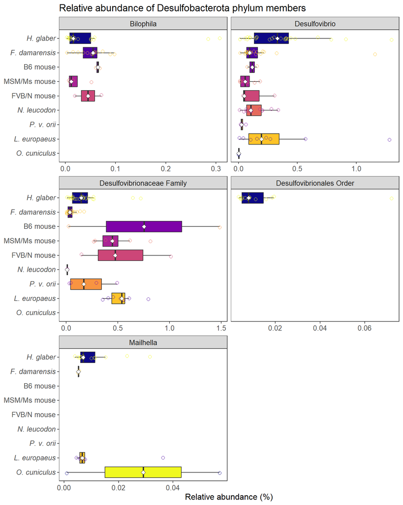

```r
print(desulfobacterota.plot +
  ggtitle(paste0("Relative abundance of Desulfobacterota phylum members"))+
  theme(plot.title = element_text(size = 14))
)
```

```r
for (image.format in c("png","tiff")){
  ggsave(file.path(community.composition.figures,
                paste0("Desulfobacterota-phylum-members-all-hosts.",
                      image.format)),
         plot=desulfobacterota.plot,
         width=8, height=10,units="in",
         dpi=300,device = image.format)
}
```

## Plot Treponema and other Spirochaetota.

```r
spirochaetota.plot<-ps.q.agg.genus.relab%>%
  mutate(class=factor(class,levels=custom.levels))%>%
  filter(Phylum=="Spirochaetota")%>%
  group_by(class,Genus)%>%
  ggplot(aes(x=factor(class,levels=rev(custom.levels)),
             y=RelativeAbundance,
             fill=factor(class)))+
  geom_boxplot(show.legend = FALSE,
               outliers = FALSE)+
  geom_jitter(aes(color=class),
              width = 0.1, # jitter spread
              shape = 1, # empty dots
              size=2,
              show.legend = FALSE)+
  scale_color_viridis_d(direction = -1,option="C")+
  facet_wrap(~Genus,scales = "free_x",
             ncol = 2)+
  theme_bw()+
  coord_flip()+
  labs(x="",
       y="Relative abundance (%)")+
  # VVV scale_x_discrete works on x axis but the final labels are on y because the coord_flip() flipped the plot.
  # So, we use rev() to address the flipping VVV
  scale_x_discrete(labels=rev(pretty.level.names), # new labels (named vector) on the axis
                   limits=rev(custom.levels) # limits adjust which levels (and in what order) are displayed
  )+ # rename boxplot labels
  scale_fill_viridis_d(option="C")+
  stat_summary(fun=median, geom="point", shape=23, size=2, color="black",fill="white",
               position = position_dodge2(width = 0.75,
                                          preserve = "single"))+
  # ggtitle(paste0("Relative abundance of Spirochaetota phylum members"))+
  taxa.plot.theme
```

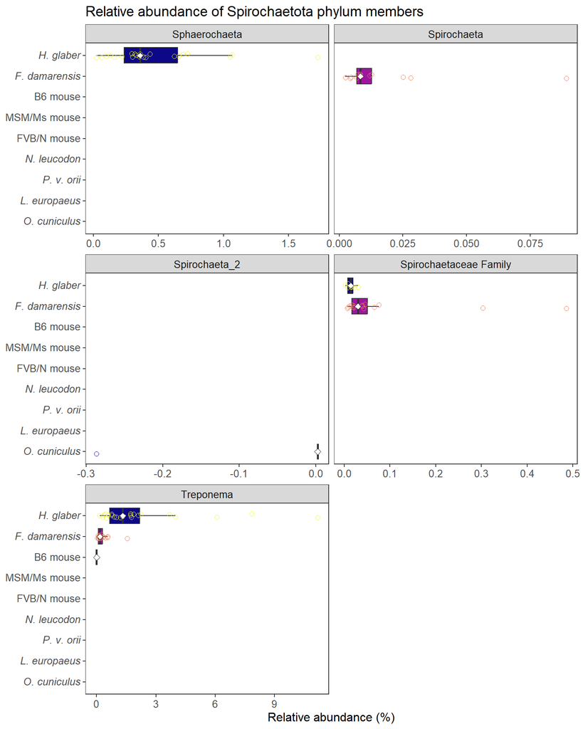

```r
print(spirochaetota.plot +
        ggtitle(paste0("Relative abundance of Spirochaetota phylum members"))+
        theme(plot.title = element_text(size = 14))
        )
```

```r
for (image.format in c("png","tiff")){
  ggsave(file.path(community.composition.figures,
                paste0("Spirochaetota-phylum-members-all-hosts.",
                      image.format)),
         plot=spirochaetota.plot,
         width=8, height=10,units="in",
         dpi=300,device = image.format)
}
```

## Analysis of naked mole-rat data ASVs.

Give ASVs shorter names: Genus, “ASV”, OTU, OTU number. For example, Allobaculum_ASV_22.

```r
nmr.asv.names<-ps.q.agg.asv.relab.nmr%>%
  dplyr::select(OTU,Genus)%>%
  group_by(Genus)%>%
  distinct(OTU,.keep_all = T)%>%
  arrange(Genus,OTU)%>%
  mutate(row.index=row_number())%>%
  mutate(ASV_name=paste(Genus,row.index,sep="_ASV_"))
knitr::kable(head(nmr.asv.names), format = "simple")
```

| OTU | Genus | row.index | ASV_name |
| --- | --- | --- | --- |
| 1630c97bc99db59912c92545f184a2c8 | ASF356 | 1 | ASF356_ASV_1 |
| a5d3cef1b84bffa024ae0259ebbe7819 | ASF356 | 2 | ASF356_ASV_2 |
| fc224cd4a1ffe36b74bdec848bbba352 | ASF356 | 3 | ASF356_ASV_3 |
| 3c23ed3c668cb5db5fe54e0920da4c77 | Absconditabacteriales_(SR1) | 1 | Absconditabacteriales_(SR1)_ASV_1 |
| 446609f70ba4143bd817f44c210a0a4c | Acetanaerobacterium | 1 | Acetanaerobacterium_ASV_1 |
| ba4f8c14f1a6f625c90f05848475b43a | Acetanaerobacterium | 2 | Acetanaerobacterium_ASV_2 |

The new name becomes the OTU column. The old name becomes OTU_old_name column.

```r
ps.q.agg.asv.relab.nmr<-ps.q.agg.asv.relab.nmr%>%
  left_join(nmr.asv.names[,c("Genus","OTU","ASV_name")])%>%
  rename("OTU_old_name"="OTU",
         "OTU"="ASV_name")%>%
  relocate(OTU,.before = Sample)%>%
  relocate(OTU_old_name,.after = Genus)
```

### How many ASVs are shared between two age groups?

First, find ASVs in young samples

```r
otu.young<-ps.q.agg.asv.relab.nmr%>%
  filter(agegroup=="agegroup0_10",Abundance!=0)%>%
  distinct(OTU,.keep_all = T)%>%
  arrange(-MeanRelativeAbundanceAgegroup)%>%
  dplyr::select(OTU,agegroup,MeanRelativeAbundanceAgegroup, sdRelativeAbundance)
```

Next, find ASVs in old samples

```r
otu.old<-ps.q.agg.asv.relab.nmr%>%
  filter(agegroup=="agegroup10_16",Abundance!=0)%>%
  distinct(OTU,.keep_all = T)%>%
  arrange(-MeanRelativeAbundanceAgegroup)%>%
  dplyr::select(OTU,agegroup,MeanRelativeAbundanceAgegroup)
```

```r
nrow(otu.young)
```

```
## [1] 1771
```

```r
nrow(otu.old)
```

```
## [1] 777
```

```r
shared.otu<-intersect(otu.young$OTU,otu.old$OTU)
length(shared.otu)
```

```
## [1] 672
```

```r
length(otu.old$OTU)-length(shared.otu)
```

```
## [1] 105
```

```r
ps.q.agg.asv.relab.nmr%>%
  group_by(OTU,agegroup)%>%
  mutate(n_samples=n_distinct(Sample))%>% # Find the number of old samples the ASV was found in
  filter(OTU %in% otu.old$OTU,
         !OTU %in% shared.otu)%>%
  filter(n_samples >= 3)%>%
  arrange(desc(MeanRelativeAbundanceAgegroup))%>%
  dplyr::select(OTU,MeanRelativeAbundance,MeanRelativeAbundanceAgegroup)
```

```
## # A tibble: 0 × 4
## # Groups:   OTU, agegroup [0]
## # ℹ 4 variables: agegroup <chr>, OTU <chr>, MeanRelativeAbundance <dbl>,
## #   MeanRelativeAbundanceAgegroup <dbl>
```

```r
ps.q.agg.asv.relab.nmr%>%
  filter(OTU %in% otu.old$OTU, # ASV in old but not shared vector
         !OTU %in% shared.otu)%>%
  dplyr::select(OTU,Family,Genus, MeanRelativeAbundance,MeanRelativeAbundanceAgegroup)%>%
  group_by(Family, Genus)%>%
  summarise(n=n_distinct(OTU))%>%
  arrange(desc(n))%>%
  head%>%
  knitr::kable(format = "simple")
```

| Family | Genus | n |
| --- | --- | --- |
| Lachnospiraceae | Lachnospiraceae Family | 14 |
| Bacteria Kingdom | Bacteria Kingdom | 11 |
| Prevotellaceae | Prevotellaceae Family | 7 |
| Spirochaetaceae | Treponema | 5 |
| Bacteroidales Order | Bacteroidales Order | 4 |
| Muribaculaceae | Muribaculaceae | 4 |

### How much % do shared ASVs take on average?

```r
ps.q.agg.asv.relab.nmr%>%
  # no separation by age
  filter(OTU%in%shared.otu)%>%
  group_by(Sample)%>%
  summarise(SumRelAbSharedASV=sum(RelativeAbundance))%>%
  summarise(MeanRelAbSharedASVTotal = mean(SumRelAbSharedASV),
            sdRelaAbSharedASVTotal = sd(SumRelAbSharedASV))
```

```
## # A tibble: 1 × 2
##   MeanRelAbSharedASVTotal sdRelaAbSharedASVTotal
##                     <dbl>                  <dbl>
## 1                    94.2                   10.9
```

On average 94.2% ± 10.9%

### How much % do shared ASVs take in each age group?

```r
ps.q.agg.asv.relab.nmr%>%
  filter(OTU%in%shared.otu)%>%
  # separation by age
  group_by(Sample,agegroup)%>%
  summarise(SumRelAbSharedASV=sum(RelativeAbundance))%>%
  arrange(agegroup)%>%
  group_by(agegroup)%>%
  summarise(MeanRelAbSharedASVTotalAge=mean(SumRelAbSharedASV),
            sdRelaAbSharedASVTotal = sd(SumRelAbSharedASV))%>%
  knitr::kable(format = "simple")
```

| agegroup | MeanRelAbSharedASVTotalAge | sdRelaAbSharedASVTotal |
| --- | --- | --- |
| agegroup0_10 | 92.61580 | 12.223912 |
| agegroup10_16 | 98.83713 | 1.766953 |

Higher variation in young individuals

### Are the shared ASVs enriched in certain genera?

First, get the table of shared ASVs and their genera.

```r
shared.otu.genera<-ps.q.agg.asv.relab.nmr%>%
  filter(OTU%in%shared.otu)%>%
  # keep unique rows
  distinct(Genus,OTU)%>%
  group_by(Genus)
knitr::kable(head(shared.otu.genera), format = "simple")
```

| Genus | OTU |
| --- | --- |
| Eubacteriaceae Family | Eubacteriaceae Family_ASV_16 |
| Allobaculum | Allobaculum_ASV_22 |
| p-251-o5 | p-251-o5_ASV_2 |
| Fibrobacter | Fibrobacter_ASV_2 |
| Erysipelotrichaceae Family | Erysipelotrichaceae Family_ASV_11 |
| Fibrobacter | Fibrobacter_ASV_5 |

Calculate the ASVs in each genus with cumsum() and pull the most numerous genera.

```r
shared.otu.genera.cumsum<-shared.otu.genera%>%
  group_by(Genus)%>%
  # count rows (ASVs) for each genus; add as a column for sorting
  summarise(num_asvs =n_distinct(OTU))%>%
  # genera with the highest number of ASVs will be on top
  arrange(-num_asvs,Genus)%>%
  ungroup()%>%
  # cumulative sum shows how many ASVs the top genera take
  mutate(cum_sum=cumsum(num_asvs))

knitr::kable(head(shared.otu.genera.cumsum), format = "simple")
```

| Genus | num_asvs | cum_sum |
| --- | --- | --- |
| Lachnospiraceae Family | 55 | 55 |
| Muribaculaceae | 54 | 109 |
| Treponema | 42 | 151 |
| Bacteria Kingdom | 30 | 181 |
| Oscillospiraceae Family | 22 | 203 |
| Parabacteroides | 22 | 225 |

### How many ASVs of the top 5 genera in shared.otu.genera are actually found there?

The five most common genera according to the shared.otu.genera dataframe are Lachnospiraceae Family (55 ASVs), Muribaculaceae (54 ASVS), Treponema (42 ASVs), Bacteria Kingdom (30 ASVs), and Oscillospiraceae Family (22 ASVs).

```r
ps.q.agg.asv.relab.nmr%>%
  filter(Genus%in%c("Lachnospiraceae Family","Treponema",
                    "Muribaculaceae","Bacteria Kingdom",
                    "Oscillospiraceae Family"))%>%
  distinct(Genus,OTU)%>%
  mutate(is_shared=ifelse(OTU %in%shared.otu.genera$OTU, TRUE, FALSE))%>%
  group_by(Genus,is_shared)%>%
  summarise(n_asvs=n())%>%
  ungroup()%>%
  arrange(Genus,desc(is_shared))%>%
  knitr::kable(format = "simple")
```

| Genus | is_shared | n_asvs |
| --- | --- | --- |
| Bacteria Kingdom | TRUE | 30 |
| Bacteria Kingdom | FALSE | 125 |
| Lachnospiraceae Family | TRUE | 55 |
| Lachnospiraceae Family | FALSE | 108 |
| Muribaculaceae | TRUE | 54 |
| Muribaculaceae | FALSE | 71 |
| Oscillospiraceae Family | TRUE | 22 |
| Oscillospiraceae Family | FALSE | 25 |
| Treponema | TRUE | 42 |
| Treponema | FALSE | 67 |

Lachnospiraceae Family: 55 ASVs are shared, 108 are not. Muribaculaceae: 54 are shared, 71 are not. Treponema: 42 ASVs are shared, 67 are not. Bacteria Kingdom: 30 ASVs are shared, 125 are not. Oscillospiraceae Family: 22 ASVs are shared, 25 are not.

### What is the average relative abundance of each genus in the top 5 of shared.otu.genera?

```r
ps.q.agg.asv.relab.nmr%>%
  # the subset command relies on the fact that we sorted the shared.otu.genera
  # by the number of ASVs. So, the unique(shared.otu.genera$Genus)[1:5] has
  # genera with the highest number of ASVs
  filter(OTU%in%subset(shared.otu.genera,
                       Genus %in% unique(shared.otu.genera.cumsum$Genus)[1:5])$OTU)%>%
  group_by(Genus,Sample)%>%
  summarise(TotalGenus=sum(RelativeAbundance))%>%
  group_by(Genus)%>%
  summarise(MeanRelAbGenus = mean(TotalGenus),
            sdRelAbGenus = sd(TotalGenus))%>%
  arrange(-MeanRelAbGenus)%>%
  knitr::kable(format = "simple")
```

| Genus | MeanRelAbGenus | sdRelAbGenus |
| --- | --- | --- |
| Muribaculaceae | 10.5567786 | 3.1527944 |
| Lachnospiraceae Family | 1.9258913 | 1.9141311 |
| Treponema | 1.9120200 | 2.2611251 |
| Oscillospiraceae Family | 0.4256199 | 0.2365284 |
| Bacteria Kingdom | 0.2820186 | 0.2012056 |

## Plot ASVs in NMR.

Setup sample levels for NMR for barplots.

```r
sample.levels<-custom.md.ages%>%
  ungroup()%>%
  dplyr::select(Sample,age)%>%
  arrange(age)%>%
  distinct()%>%
  mutate(NewSample=paste0(Sample," (",age,")"))%>%
  mutate(Sample=factor(Sample,levels=Sample),
         NewSample=factor(NewSample,levels=NewSample))
```

Bar plot of abundances: high variability

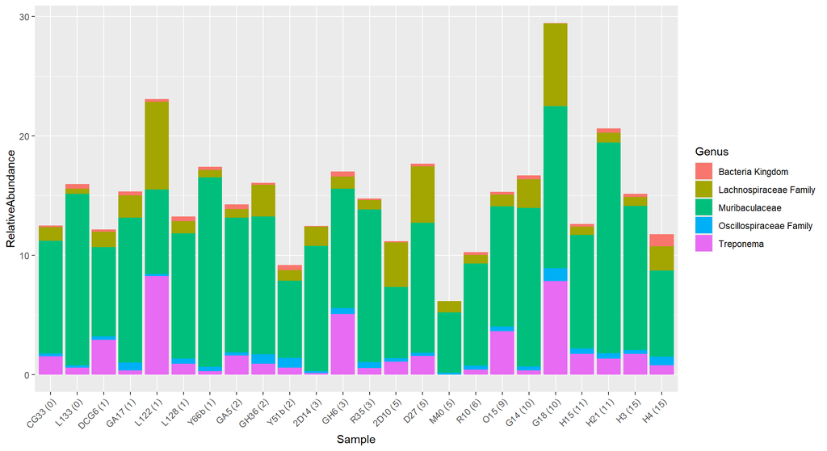

```r
ps.q.agg.asv.relab.nmr%>%
  left_join(custom.md.ages)%>%
  mutate(Sample=factor(Sample,levels=sample.levels$Sample),
         NewSample=paste0(Sample," (",age,")"),
         NewSample=factor(NewSample,levels=sample.levels$NewSample))%>%
  filter(OTU%in%subset(shared.otu.genera,
                       Genus%in%unique(shared.otu.genera.cumsum$Genus)[1:5])$OTU)%>%
  ggplot(aes(x=NewSample,y=RelativeAbundance,fill=Genus))+
  geom_bar(stat="identity")+
  labs(x = "Sample")+
  theme(axis.text.x = element_text(angle = 45, hjust=1))
```

Find the most abundant ASVs on average.

```r
top10.asv.average<-ps.q.agg.asv.relab.nmr%>%
  filter(OTU%in%shared.otu)%>%
  group_by(OTU)%>%
  distinct(OTU,.keep_all = T)%>%
  arrange(-MeanRelativeAbundance)%>%
  dplyr::select(Genus,OTU,MeanRelativeAbundance)%>%
  head(n=10)
top10.asv.average%>%
  arrange(Genus)%>%
  knitr::kable(format = "simple")
```

| Genus | OTU | MeanRelativeAbundance |
| --- | --- | --- |
| Allobaculum | Allobaculum_ASV_22 | 3.278265 |
| Erysipelotrichaceae Family | Erysipelotrichaceae Family_ASV_11 | 4.143506 |
| Eubacteriaceae Family | Eubacteriaceae Family_ASV_16 | 1.736766 |
| Eubacteriaceae Family | Eubacteriaceae Family_ASV_4 | 1.673555 |
| Fibrobacter | Fibrobacter_ASV_2 | 4.156885 |
| Prevotella | Prevotella_ASV_7 | 2.345587 |
| Prevotellaceae Family | Prevotellaceae Family_ASV_31 | 2.480406 |
| Prevotellaceae_UCG-003 | Prevotellaceae_UCG-003_ASV_13 | 2.676864 |
| Prevotellaceae_UCG-003 | Prevotellaceae_UCG-003_ASV_2 | 1.530395 |
| p-251-o5 | p-251-o5_ASV_2 | 6.303360 |

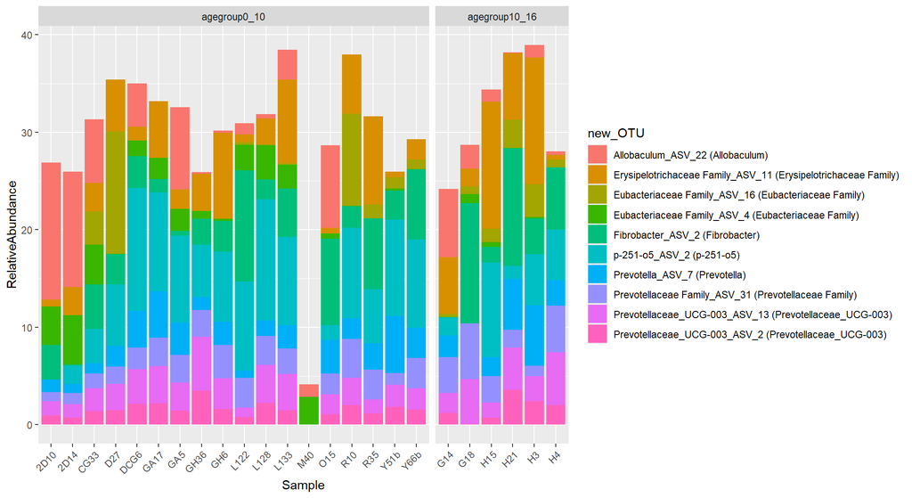

```r
ps.q.agg.asv.relab.nmr%>%
  filter(OTU%in%top10.asv.average$OTU)%>%
  mutate(new_OTU=paste0(OTU," (",Genus,")"))%>%
  ggplot(aes(x=Sample,y=RelativeAbundance,fill=new_OTU))+
  geom_bar(stat="identity")+
  facet_grid(~agegroup,
             scales="free",
             space = "free")+
  labs(x = "Sample")+
  theme(axis.text.x = element_text(angle = 45, hjust=1))
```

```r
### 17.2 Most abundant shared ASVs in each age group. ####
```

### Most abundant shared ASVs in each age group.

```r
top.shared.asvs.by_age<-ps.q.agg.asv.relab.nmr%>%
  filter(OTU%in%shared.otu)%>%
  group_by(OTU,agegroup)%>%
  distinct(OTU,.keep_all = T)%>%
  arrange(-MeanRelativeAbundance)%>%
  dplyr::select(Genus,OTU,agegroup,MeanRelativeAbundance,MeanRelativeAbundanceAgegroup)%>%
  ungroup()
knitr::kable(head(top.shared.asvs.by_age), format = "simple")
```

| Genus | OTU | agegroup | MeanRelativeAbundance | MeanRelativeAbundanceAgegroup |
| --- | --- | --- | --- | --- |
| p-251-o5 | p-251-o5_ASV_2 | agegroup0_10 | 6.303360 | 6.655592 |
| p-251-o5 | p-251-o5_ASV_2 | agegroup10_16 | 6.303360 | 4.013295 |
| Fibrobacter | Fibrobacter_ASV_2 | agegroup0_10 | 4.156885 | 3.899673 |
| Fibrobacter | Fibrobacter_ASV_2 | agegroup10_16 | 4.156885 | 5.829172 |
| Erysipelotrichaceae Family | Erysipelotrichaceae Family_ASV_11 | agegroup0_10 | 4.143506 | 3.732994 |
| Erysipelotrichaceae Family | Erysipelotrichaceae Family_ASV_11 | agegroup10_16 | 4.143506 | 6.812484 |

```r
top10.shared.asv.young<-top.shared.asvs.by_age%>%
  filter(agegroup=="agegroup0_10")%>%
  arrange(-MeanRelativeAbundanceAgegroup)%>%
  head(n=10)

top10.shared.asv.old<-top.shared.asvs.by_age%>%
  filter(agegroup=="agegroup10_16")%>%
  arrange(-MeanRelativeAbundanceAgegroup)%>%
  head(n=10)
```

Are top 10 most abundant ASVs same in two age groups?

```r
setequal(top10.shared.asv.young$OTU,top10.shared.asv.old$OTU)
```

```
## [1] FALSE
```

No. How many are common?

```r
intersect(top10.shared.asv.young$OTU,top10.shared.asv.old$OTU)
```

```
## [1] "p-251-o5_ASV_2"                    "Fibrobacter_ASV_2"
## [3] "Erysipelotrichaceae Family_ASV_11" "Allobaculum_ASV_22"
## [5] "Prevotellaceae_UCG-003_ASV_13"     "Prevotellaceae Family_ASV_31"
## [7] "Prevotella_ASV_7"
```

Seven ASVs

Union of the top 10 ASVs in each of the two age groups.

```r
top10.shared.asv.union<-sort(union(top10.shared.asv.young$OTU,top10.shared.asv.old$OTU))
```

Make the names shorter for the barplot

```r
top10.shared.asv.union<-top10.shared.asv.union%>%
  as_tibble()%>%
  rename("OTU"="value")%>%
  mutate(new_OTU = OTU,
         new_OTU = gsub("Allobaculum_", "Allob. ",new_OTU),
         new_OTU = gsub("Erysipelotrichaceae Family_", "Erysip. F. ",new_OTU),
         new_OTU = gsub("Eubacteriaceae Family_", "Eubac. F. ",new_OTU),
         new_OTU = gsub("Fibrobacter_", "Fibrob. ",new_OTU),
         new_OTU = gsub("Muribaculaceae_", "Murib. ",new_OTU),
         new_OTU = gsub("Paludibacteraceae Family_", "Palud. F. ",new_OTU),
         new_OTU = gsub("o5_ASV", "o5 ASV",new_OTU),
         new_OTU = gsub("Prevotella_", "Prev. ",new_OTU),
         new_OTU = gsub("Prevotellaceae Family_", "Prevot. F. ",new_OTU),
         new_OTU = gsub("Prevotellaceae_UCG", "Prevot. UCG",new_OTU),
         new_OTU = gsub("UCG-001_", "UCG-001 ",new_OTU),
         new_OTU = gsub("UCG-003_", "UCG-003 ",new_OTU)
         )
```

Prepare a custom fill with Polychrome package

```r
set.seed(1)
otu.fill<-createPalette(nrow(top10.shared.asv.union),
                        seedcolors = c("#FF0000", "#00FF00", "#0000FF"),
                        range=c(30, 80))
names(otu.fill)<-top10.shared.asv.union$new_OTU
```

### Barplot of the most abundant ASVs.

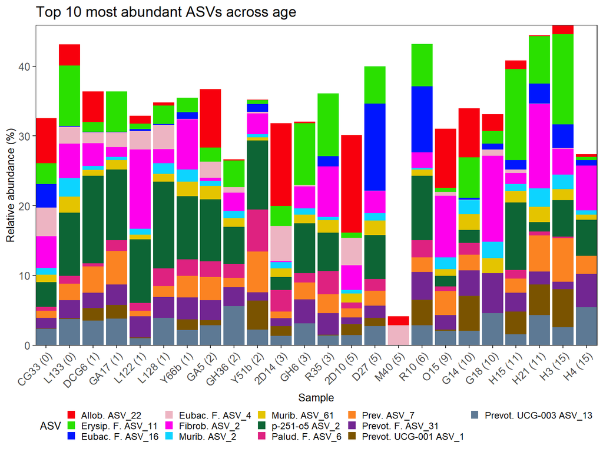

```r
top10.shared.asv.plot<-ps.q.agg.asv.relab.nmr%>%
  left_join(custom.md.ages)%>%
  filter(OTU%in%top10.shared.asv.union$OTU) %>%
  # mutate(new_OTU=paste0(OTU," (",Genus,")"))%>%
  left_join(top10.shared.asv.union)%>%
  mutate(Sample=factor(Sample,levels=sample.levels$Sample),
         NewSample=paste0(Sample," (",age,")"),
         NewSample=factor(NewSample,levels=sample.levels$NewSample))%>%

  ggplot(aes(x=NewSample,y=RelativeAbundance,fill=new_OTU))+
  geom_bar(stat="identity")+
  scale_fill_manual(labels=names(otu.fill),
                    values=otu.fill)+
  theme_bw()+
  coord_cartesian(expand = FALSE)+
  labs(x="Sample",
       y="Relative abundance (%)",
       # title="Top 10 most abundant ASVs across age",
       fill="ASV"
       )+
  project_theme +
  asv.barplot.theme +
  theme (plot.title = element_text(size = 8))
print(top10.shared.asv.plot+
  ggtitle("Top 10 most abundant ASVs across age")+
  theme(plot.title = element_text(size = 14)))
```

```r
for(image.format in image.formats){
  ggsave(file.path(community.composition.figures,
                 paste0("top10-asv.", image.format)),
       plot=top10.shared.asv.plot,
       width=8, height=6,units="in",
       dpi=300,device = image.format)
}
```

### M40 sample is very different.

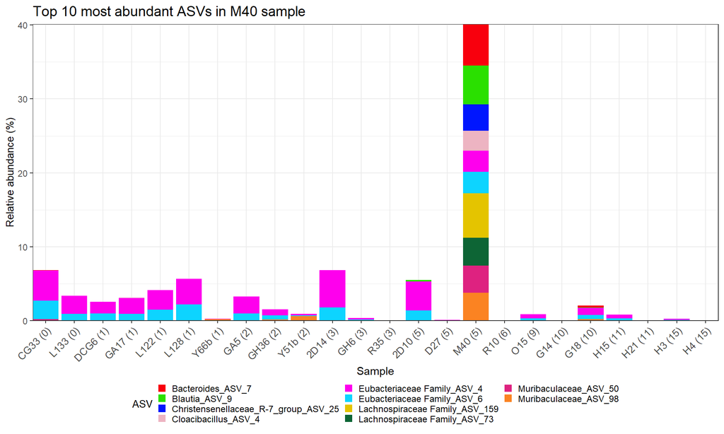

```r
m40.asvs<-ps.q.agg.asv.relab.nmr%>%
  filter(Sample=="M40")%>%
  dplyr::select(OTU,Genus,RelativeAbundance,MeanRelativeAbundance,
         MeanRelativeAbundanceAgegroup)%>%
  arrange(-RelativeAbundance)%>%
  head(n=10)

set.seed(1)
m40.otu.fill<-createPalette(length(m40.asvs$OTU),
                            seedcolors = c("#FF0000", "#00FF00", "#0000FF"),
                            range=c(30, 80))
names(m40.otu.fill)<-sort(m40.asvs$OTU)
m40.asv.plot<-ps.q.agg.asv.relab.nmr%>%
  left_join(custom.md.ages)%>%
  mutate(Sample=factor(Sample,levels=sample.levels$Sample),
         NewSample=paste0(Sample," (",age,")"),
         NewSample=factor(NewSample,levels=sample.levels$NewSample))%>%
  filter(OTU%in%m40.asvs$OTU)%>%
  # mutate(new_OTU=paste0(OTU," (",Genus,")"))%>%
  ggplot(aes(x=NewSample,y=RelativeAbundance,fill=OTU))+
  geom_bar(stat="identity")+
  scale_fill_manual(labels=names(m40.otu.fill),
                    values=m40.otu.fill)+
  theme_bw()+
  coord_cartesian(expand = FALSE)+
  labs(x="Sample",
       y="Relative abundance (%)",
       fill="ASV",
       title="Top 10 most abundant ASVs in M40 sample")+
  guides(fill = guide_legend(ncol = 3))+
  asv.barplot.theme
print(m40.asv.plot)
```

```r
ggsave(file.path(community.composition.figures,
                 paste("top10-asv-m40.png")),
       plot = m40.asv.plot,
       width=8, height=6,units="in",
       dpi=300,device = "png")
```

## Analyse age groups in detail.

### Let’s find which major ASVs are specific to one age group

```r
young.ps.q.agg.asv.relab.nmr<-ps.q.agg.asv.relab.nmr%>%
  filter(agegroup=="agegroup0_10")%>%
  arrange(-MeanRelativeAbundanceAgegroup)

old.ps.q.agg.asv.relab.nmr<-ps.q.agg.asv.relab.nmr%>%
  filter(agegroup=="agegroup10_16")%>%
  arrange(-MeanRelativeAbundanceAgegroup)

length(unique(young.ps.q.agg.asv.relab.nmr$OTU))
```

```
## [1] 1771
```

```r
length(unique(old.ps.q.agg.asv.relab.nmr$OTU))
```

```
## [1] 777
```

### How many genera are shared between two age groups

```r
genera.young<-ps.q.agg.genus.relab.nmr%>%
  # add_agegroup_to_tax_df(.,"Genus",custom.md.ages)%>%
  # left_join(custom.md.ages)%>%
  filter(agegroup=="agegroup0_10",Abundance!=0)%>%
  distinct(Genus,.keep_all = T)%>%
  arrange(-MeanRelativeAbundanceAgegroup)
genera.old<-ps.q.agg.genus.relab.nmr%>%
  # add_agegroup_to_tax_df(.,"Genus",custom.md.ages)%>%
  # left_join(custom.md.ages)%>%
  filter(agegroup=="agegroup10_16",Abundance!=0)%>%
  distinct(Genus,.keep_all = T)%>%
  arrange(-MeanRelativeAbundanceAgegroup)

length(genera.young$Genus)
```

```
## [1] 233
```

```r
length(genera.old$Genus)
```

```
## [1] 159
```

```r
shared.genera<-intersect(genera.young$Genus,genera.old$Genus)
length(shared.genera)
```

```
## [1] 157
```

```r
unique.to_old.genera<-setdiff(genera.old$Genus,genera.young$Genus)
ps.q.agg.genus.relab.nmr%>%
  # add_agegroup_to_tax_df(.,"Genus",custom.md.ages)%>%
  filter(Genus %in% unique.to_old.genera)%>%
  dplyr::select(Sample,Family,Genus,MeanRelativeAbundance,
                MeanRelativeAbundanceAgegroup )%>%
  knitr::kable(format = "simple")
```

| Sample | Family | Genus | MeanRelativeAbundance | MeanRelativeAbundanceAgegroup |
| --- | --- | --- | --- | --- |
| G18 | Lachnospiraceae | Roseburia | 0.0014083 | 0.0105645 |
| G14 | Veillonellaceae | Veillonella | 0.0004333 | 0.0032506 |
| H15 | Veillonellaceae | Veillonella | 0.0004333 | 0.0032506 |

```r
# How much % do common genera take in each age group on average?
ps.q.agg.asv.relab.nmr%>%
  filter(Genus%in%shared.genera)%>%
  group_by(Sample,agegroup)%>%
  summarise(SumRelAbCommonASV=sum(RelativeAbundance))%>%
  arrange(agegroup)%>%
  group_by(agegroup)%>%
  summarise(MeanRelAbCommonASVTotalAge=mean(SumRelAbCommonASV))%>%
  knitr::kable(format = "simple")
```

| agegroup | MeanRelAbCommonASVTotalAge |
| --- | --- |
| agegroup0_10 | 99.58753 |
| agegroup10_16 | 99.98543 |

```r
rm(list = ls(all=TRUE))
gc()
```

```
##           used  (Mb) gc trigger  (Mb) max used  (Mb)
## Ncells 2997487 160.1    4463469 238.4  4463469 238.4
## Vcells 5308656  40.6   23211478 177.1 23211275 177.1
```